# Exploratory Data Analysis

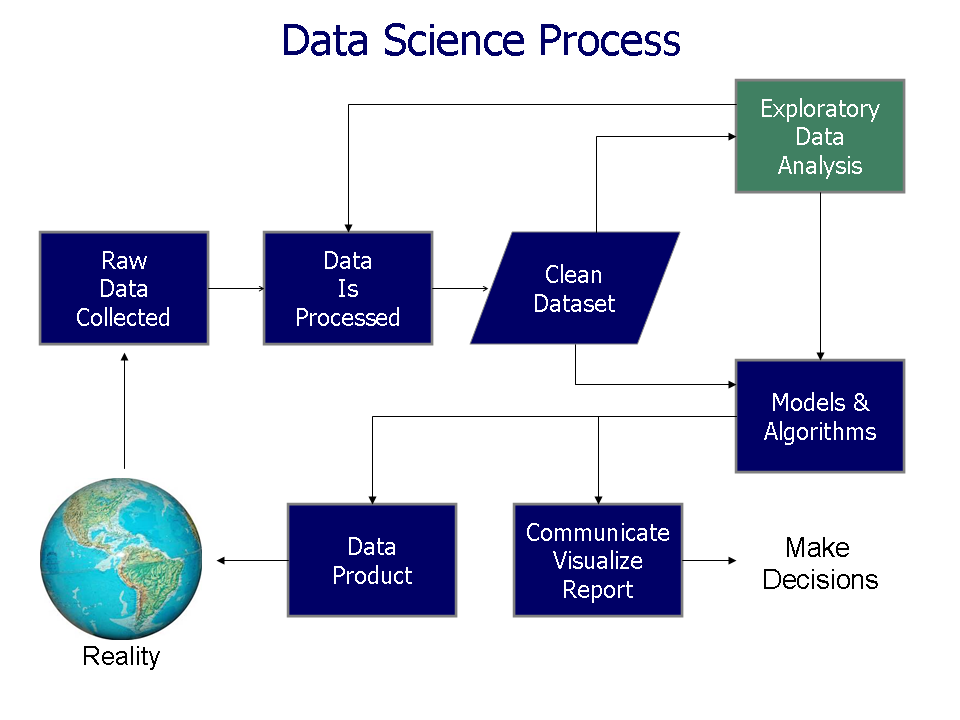

*image from [Wikipedia](https://en.wikipedia.org/wiki/Exploratory_data_analysis)*

## Customer Churn

Also known as customer attrition, or customer turnover is the loss of clients or customers. Customer churn is a critical metric because it is much less expensive to retain existing customers than it is to acquire new ones.

Companies usually make a distinction between voluntary churn and involuntary churn. In most analyses involuntary churn is excluded.

Predictive analytics uses machine learning to predict the likelihood of a customer churning. These models will identify a small subgroup of potential customers that are at a higher risk of abandoning the company. This empowers the company to focus on the subset of the customers who are most likely to churn and through customer retention marketing programs stop some of that to happen.

## Data

**Telco Customer Churn**

The data was downloaded from IBM Sample Data Sets: https://www.ibm.com/communities/analytics/watson-analytics-blog/guide-to-sample-datasets/

Each row represents a customer, each column contains customer’s attributes described as below:

- **customerID**: Customer ID
- **gender**: Customer gender (female, male)
- **SeniorCitizen**: Whether the customer is a senior citizen or not (1, 0)
- **Partner**: Whether the customer has a partner or not (Yes, No)
- **Dependents**: Whether the customer has dependents or not (Yes, No)
- **tenure**: Number of months the customer has stayed with the company
- **PhoneService**: Whether the customer has a phone service or not (Yes, No)
- **MultipleLines**: Whether the customer has multiple lines or not (Yes, No, No phone service)
- **InternetService**: Customer’s internet service provider (DSL, Fiber optic, No)
- **OnlineSecurity**: Whether the customer has online security or not (Yes, No, No internet service)
- **OnlineBackup**: Whether the customer has online backup or not (Yes, No, No internet service)
- **DeviceProtection**: Whether the customer has device protection or not (Yes, No, No internet service)
- **TechSupport**: Whether the customer has tech support or not (Yes, No, No internet service)
- **StreamingTV**: Whether the customer has streaming TV or not (Yes, No, No internet service)
- **StreamingMovies**: Whether the customer has streaming movies or not (Yes, No, No internet service)
- **Contract**: The contract term of the customer (Month-to-month, One year, Two year)
- **PaperlessBilling**: Whether the customer has paperless billing or not (Yes, No)
- **PaymentMethod**: The customer’s payment method (Electronic check, Mailed check, Bank transfer (automatic), Credit card (automatic))
- **MonthlyCharges**: The amount charged to the customer monthly
- **TotalCharges**: The total amount charged to the customer
- **Churn**: Whether the customer churned or not (Yes or No)

The data set includes information about:

- Customers who left - the column is called `Churn`
- Services that each customer has signed up for - phone, multiple lines, internet, online security, online backup, device protection, tech support, and streaming TV and movies
- Customer account information - how long they’ve been a customer, contract, payment method, paperless billing, monthly charges, and total charges
- Demographic info about customers - gender, age range, and if they have partners and dependents

Loading the data into a dataframe:

```r
telcoChurnDf <- read_csv("../data/Telco-Customer-Churn.csv",
                         col_types = list(gender = col_factor(),
                                          SeniorCitizen = col_factor(),
                                          Partner = col_factor(),
                                          Dependents = col_factor(),
                                          PhoneService = col_factor(),
                                          MultipleLines = col_factor(),
                                          InternetService = col_factor(),
                                          OnlineSecurity = col_factor(),
                                          OnlineBackup = col_factor(),
                                          DeviceProtection = col_factor(),
                                          TechSupport = col_factor(),
                                          StreamingTV = col_factor(),
                                          StreamingMovies = col_factor(),
                                          Contract = col_factor(),
                                          PaperlessBilling = col_factor(),
                                          PaymentMethod = col_factor(),
                                          Churn = col_factor()))
```

```r
glimpse(telcoChurnDf)
```

```
Observations: 7,043
Variables: 21
$ customerID       <chr> "7590-VHVEG", "5575-GNVDE", "3668-QPYBK", "7795-CFOCW", "9237-H…
$ gender           <fct> Female, Male, Male, Male, Female, Female, Male, Female, Female,…
$ SeniorCitizen    <fct> 0, 0, 0, 0, 0, 0, 0, 0, 0, 0, 0, 0, 0, 0, 0, 0, 0, 0, 0, 0, 1, …
$ Partner          <fct> Yes, No, No, No, No, No, No, No, Yes, No, Yes, No, Yes, No, No,…
$ Dependents       <fct> No, No, No, No, No, No, Yes, No, No, Yes, Yes, No, No, No, No, …
$ tenure           <dbl> 1, 34, 2, 45, 2, 8, 22, 10, 28, 62, 13, 16, 58, 49, 25, 69, 52,…
$ PhoneService     <fct> No, Yes, Yes, No, Yes, Yes, Yes, No, Yes, Yes, Yes, Yes, Yes, Y…
$ MultipleLines    <fct> No phone service, No, No, No phone service, No, Yes, Yes, No ph…
$ InternetService  <fct> DSL, DSL, DSL, DSL, Fiber optic, Fiber optic, Fiber optic, DSL,…
$ OnlineSecurity   <fct> No, Yes, Yes, Yes, No, No, No, Yes, No, Yes, Yes, No internet s…
$ OnlineBackup     <fct> Yes, No, Yes, No, No, No, Yes, No, No, Yes, No, No internet ser…
$ DeviceProtection <fct> No, Yes, No, Yes, No, Yes, No, No, Yes, No, No, No internet ser…
$ TechSupport      <fct> No, No, No, Yes, No, No, No, No, Yes, No, No, No internet servi…
$ StreamingTV      <fct> No, No, No, No, No, Yes, Yes, No, Yes, No, No, No internet serv…
$ StreamingMovies  <fct> No, No, No, No, No, Yes, No, No, Yes, No, No, No internet servi…
$ Contract         <fct> Month-to-month, One year, Month-to-month, One year, Month-to-mo…
$ PaperlessBilling <fct> Yes, No, Yes, No, Yes, Yes, Yes, No, Yes, No, Yes, No, No, Yes,…
$ PaymentMethod    <fct> Electronic check, Mailed check, Mailed check, Bank transfer (au…
$ MonthlyCharges   <dbl> 29.85, 56.95, 53.85, 42.30, 70.70, 99.65, 89.10, 29.75, 104.80,…
$ TotalCharges     <dbl> 29.85, 1889.50, 108.15, 1840.75, 151.65, 820.50, 1949.40, 301.9…
$ Churn            <fct> No, No, Yes, No, Yes, Yes, No, No, Yes, No, No, No, No, Yes, No…
```

7043 observations with 21 variables.

All the columns have been loaded with the correct data type.

Can you spot any missing values?

```r
summary(telcoChurnDf)
```

```
  customerID           gender     SeniorCitizen Partner    Dependents     tenure
 Length:7043        Female:3488   0:5901        Yes:3402   No :4933   Min.   : 0.00
 Class :character   Male  :3555   1:1142        No :3641   Yes:2110   1st Qu.: 9.00
 Mode  :character                                                     Median :29.00
                                                                      Mean   :32.37
                                                                      3rd Qu.:55.00
                                                                      Max.   :72.00

 PhoneService          MultipleLines     InternetService             OnlineSecurity
 No : 682     No phone service: 682   DSL        :2421   No                 :3498
 Yes:6361     No              :3390   Fiber optic:3096   Yes                :2019
              Yes             :2971   No         :1526   No internet service:1526




              OnlineBackup             DeviceProtection              TechSupport
 Yes                :2429   No                 :3095    No                 :3473
 No                 :3088   Yes                :2422    Yes                :2044
 No internet service:1526   No internet service:1526    No internet service:1526




              StreamingTV              StreamingMovies           Contract
 No                 :2810   No                 :2785   Month-to-month:3875
 Yes                :2707   Yes                :2732   One year      :1473
 No internet service:1526   No internet service:1526   Two year      :1695




 PaperlessBilling                   PaymentMethod  MonthlyCharges    TotalCharges
 Yes:4171         Electronic check         :2365   Min.   : 18.25   Min.   :  18.8
 No :2872         Mailed check             :1612   1st Qu.: 35.50   1st Qu.: 401.4
                  Bank transfer (automatic):1544   Median : 70.35   Median :1397.5
                  Credit card (automatic)  :1522   Mean   : 64.76   Mean   :2283.3
                                                   3rd Qu.: 89.85   3rd Qu.:3794.7
                                                   Max.   :118.75   Max.   :8684.8
                                                                    NA's   :11
 Churn
 No :5174
 Yes:1869
```

Looks like `TotalCharges` has 11 missing values.

**Checking for missing value**

We could also separately check for missing values. Below we are using `map_int()` from the package *purrr*:

```r
map_int(telcoChurnDf, function(x) sum(is.na(x)))
```

```
      customerID           gender    SeniorCitizen          Partner       Dependents
               0                0                0                0                0
          tenure     PhoneService    MultipleLines  InternetService   OnlineSecurity
               0                0                0                0                0
    OnlineBackup DeviceProtection      TechSupport      StreamingTV  StreamingMovies
               0                0                0                0                0
        Contract PaperlessBilling    PaymentMethod   MonthlyCharges     TotalCharges
               0                0                0                0               11
           Churn
               0
```

Let’s have a look at the rows that are missing `TotalCharges`:

```r
telcoChurnDf %>%
  filter(is.na(TotalCharges))
```

| customerID | gender | SeniorCitizen | Partner | Dependents | tenure | PhoneService | MultipleLines | InternetService | OnlineSecurity | OnlineBackup | DeviceProtection | TechSupport | StreamingTV | StreamingMovies | Contract | PaperlessBilling | PaymentMethod | MonthlyCharges | TotalCharges | Churn |
| --- | --- | --- | --- | --- | --- | --- | --- | --- | --- | --- | --- | --- | --- | --- | --- | --- | --- | --- | --- | --- |
| 4472-LVYGI | Female | 0 | Yes | Yes | 0 | No | No phone service | DSL | Yes | No | Yes | Yes | Yes | No | Two year | Yes | Bank transfer (automatic) | 52.55 | NA | No |
| 3115-CZMZD | Male | 0 | No | Yes | 0 | Yes | No | No | No internet service | No internet service | No internet service | No internet service | No internet service | No internet service | Two year | No | Mailed check | 20.25 | NA | No |
| 5709-LVOEQ | Female | 0 | Yes | Yes | 0 | Yes | No | DSL | Yes | Yes | Yes | No | Yes | Yes | Two year | No | Mailed check | 80.85 | NA | No |
| 4367-NUYAO | Male | 0 | Yes | Yes | 0 | Yes | Yes | No | No internet service | No internet service | No internet service | No internet service | No internet service | No internet service | Two year | No | Mailed check | 25.75 | NA | No |
| 1371-DWPAZ | Female | 0 | Yes | Yes | 0 | No | No phone service | DSL | Yes | Yes | Yes | Yes | Yes | No | Two year | No | Credit card (automatic) | 56.05 | NA | No |
| 7644-OMVMY | Male | 0 | Yes | Yes | 0 | Yes | No | No | No internet service | No internet service | No internet service | No internet service | No internet service | No internet service | Two year | No | Mailed check | 19.85 | NA | No |
| 3213-VVOLG | Male | 0 | Yes | Yes | 0 | Yes | Yes | No | No internet service | No internet service | No internet service | No internet service | No internet service | No internet service | Two year | No | Mailed check | 25.35 | NA | No |
| 2520-SGTTA | Female | 0 | Yes | Yes | 0 | Yes | No | No | No internet service | No internet service | No internet service | No internet service | No internet service | No internet service | Two year | No | Mailed check | 20.00 | NA | No |
| 2923-ARZLG | Male | 0 | Yes | Yes | 0 | Yes | No | No | No internet service | No internet service | No internet service | No internet service | No internet service | No internet service | One year | Yes | Mailed check | 19.70 | NA | No |
| 4075-WKNIU | Female | 0 | Yes | Yes | 0 | Yes | Yes | DSL | No | Yes | Yes | Yes | Yes | No | Two year | No | Mailed check | 73.35 | NA | No |

[output cut: 1 more lines]

- There are only 11 missing data in the `TotalCharges` field. Everything about these customers seem normal but perhaps they are new so they haven’t received any charges yet. Since this is not a significant number of customers we will remove them from the dataset.
- `customerID` has no potential predictive or descriptive power, so we will drop that column.
- `Churn` column will be used very often, for a higher visibility let’s bring that to the front.
- We will leave the original dataset (`telcoChurnDf`) untouched, and save all of these changes to a new dataframe (`churnDf`):

```r
# Remove unnecessary data
churnDf <- telcoChurnDf %>%
  select(-customerID) %>% # Dropping customerID column since has no predictive info
  drop_na() %>% # This will remove 11 rows where TotalCharges is NA
  select(Churn, everything()) # Reordering the columns to keep churn as first
```

There are three continuous variables: * `Tenure` * `MonthlyCharges` * `TotalCharges`

```r
churnDf$SeniorCitizen <- ifelse(churnDf$SeniorCitizen==1, 'Yes', 'No')
```

```r
glimpse(churnDf)
```

```
Observations: 7,032
Variables: 20
$ Churn            <fct> No, No, Yes, No, Yes, Yes, No, No, Yes, No, No, No, No, Yes, No…
$ gender           <fct> Female, Male, Male, Male, Female, Female, Male, Female, Female,…
$ SeniorCitizen    <chr> "No", "No", "No", "No", "No", "No", "No", "No", "No", "No", "No…
$ Partner          <fct> Yes, No, No, No, No, No, No, No, Yes, No, Yes, No, Yes, No, No,…
$ Dependents       <fct> No, No, No, No, No, No, Yes, No, No, Yes, Yes, No, No, No, No, …
$ tenure           <dbl> 1, 34, 2, 45, 2, 8, 22, 10, 28, 62, 13, 16, 58, 49, 25, 69, 52,…
$ PhoneService     <fct> No, Yes, Yes, No, Yes, Yes, Yes, No, Yes, Yes, Yes, Yes, Yes, Y…
$ MultipleLines    <fct> No phone service, No, No, No phone service, No, Yes, Yes, No ph…
$ InternetService  <fct> DSL, DSL, DSL, DSL, Fiber optic, Fiber optic, Fiber optic, DSL,…
$ OnlineSecurity   <fct> No, Yes, Yes, Yes, No, No, No, Yes, No, Yes, Yes, No internet s…
$ OnlineBackup     <fct> Yes, No, Yes, No, No, No, Yes, No, No, Yes, No, No internet ser…
$ DeviceProtection <fct> No, Yes, No, Yes, No, Yes, No, No, Yes, No, No, No internet ser…
$ TechSupport      <fct> No, No, No, Yes, No, No, No, No, Yes, No, No, No internet servi…
$ StreamingTV      <fct> No, No, No, No, No, Yes, Yes, No, Yes, No, No, No internet serv…
$ StreamingMovies  <fct> No, No, No, No, No, Yes, No, No, Yes, No, No, No internet servi…
$ Contract         <fct> Month-to-month, One year, Month-to-month, One year, Month-to-mo…
$ PaperlessBilling <fct> Yes, No, Yes, No, Yes, Yes, Yes, No, Yes, No, Yes, No, No, Yes,…
$ PaymentMethod    <fct> Electronic check, Mailed check, Mailed check, Bank transfer (au…
$ MonthlyCharges   <dbl> 29.85, 56.95, 53.85, 42.30, 70.70, 99.65, 89.10, 29.75, 104.80,…
$ TotalCharges     <dbl> 29.85, 1889.50, 108.15, 1840.75, 151.65, 820.50, 1949.40, 301.9…
```

## Visualizing the categorical variables with respect to `Churn`

Create a bar chart showing the distribution of churned customers:

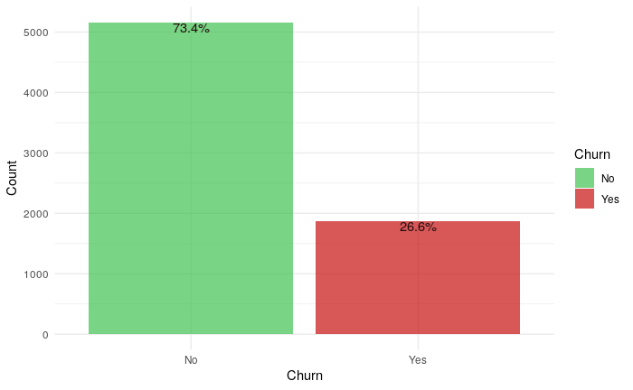

```r
ggplot(churnDf, aes(x=Churn, fill = Churn)) +
  geom_bar(alpha = 2/3) +
  labs(y = "Count") +
  geom_text(aes(y = (..count..),
                label = paste0(round(..count../sum(..count..)*100, 1), "%")),
            stat = "count", color = "#230e0d", vjust = 1) +
  scale_fill_manual( values = c("#37bf49", "#c40505")) +
  theme_minimal() -> p1
p1
```

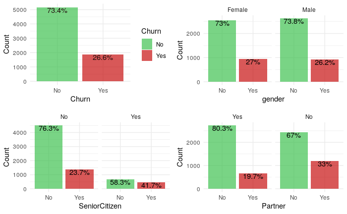

```r
multiplot(p1,
          Churn_vs_var_plot(churnDf, "gender"),
          Churn_vs_var_plot(churnDf, "SeniorCitizen"),
          Churn_vs_var_plot(churnDf, "Partner"),
          layout=matrix(c(1,2,3,4),2,2,byrow=TRUE))
```

- **`Churn`** - The data shows that about one forth of the customers churned.
- **`gender`** - The churn percent is almost equal for both Male and Female.
- **`SeniorCitizen`** - The rate of churn is almost double in case of senior citizens.
- **`Partner`** - Customers with partners have lower churn rate.

Create a plot of with `multiplot()` describing Dependents, PhoneService, MultipleLines, and InternetService:

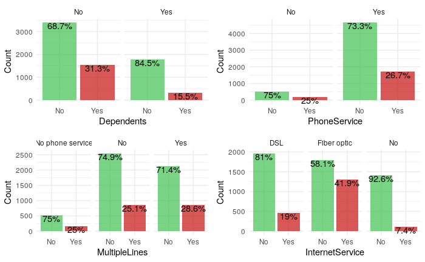

```r
multiplot(Churn_vs_var_plot(churnDf, "Dependents"),
          Churn_vs_var_plot(churnDf, "PhoneService"),
          Churn_vs_var_plot(churnDf, "MultipleLines"),
          Churn_vs_var_plot(churnDf, "InternetService"),
          layout=matrix(c(1,2,3,4),2,2,byrow=TRUE))
```

- **`Dependents`** - Customers with dependents have lower churn rate (almost half the ones without dependents).
- **`PhoneService`** - There is no significant difference among the ones with phone service and without.
- **`MultipleLines`** - There is no significant difference among the ones with multiple lines and without.
- **`InternetService`** - Seems that the customers with Fiber Optic Internet Service have a much higher churn rate compared to the ones with DSL or no Internet Services. We see a very small rate of leaving for customers with no internet services.

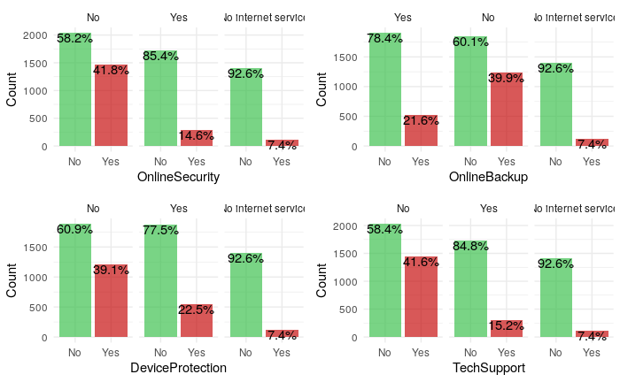

```r
multiplot(Churn_vs_var_plot(churnDf, "OnlineSecurity", F),
          Churn_vs_var_plot(churnDf, "OnlineBackup", F),
          Churn_vs_var_plot(churnDf, "DeviceProtection", F),
          Churn_vs_var_plot(churnDf, "TechSupport", F),
          layout=matrix(c(1,2,3,4),2,2,byrow=TRUE))
```

- Customers who did not use these services left the company at a much higher rate: **`OnlineSecurity`**, **`OnlineBackup`**, **`DeviceProtection`**, and **`TechSupport`**.

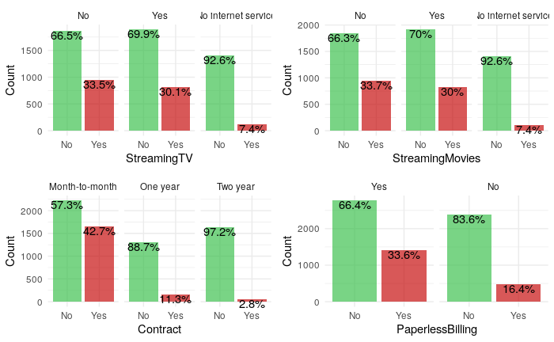

```r
multiplot(Churn_vs_var_plot(churnDf, "StreamingTV"),
          Churn_vs_var_plot(churnDf, "StreamingMovies"),
          Churn_vs_var_plot(churnDf, "Contract"),
          Churn_vs_var_plot(churnDf, "PaperlessBilling"),
          layout=matrix(c(1,2,3,4), 2, 2, byrow=TRUE))
```

- We saw that customers with no internet service have a higher tendency to stick with the company, hence a very low churn rate. This is also evident from **`StreamingTV`** and **`StreamingMovies`**.
- **`Contract`** - A large percentage of customers with “Month-to-Month” contract have left the company, when compared to the customers that are bound to one or two years contract.
- **`PaperlessBilling`** - Churn percent is higher in case of customers having paperless billing option.

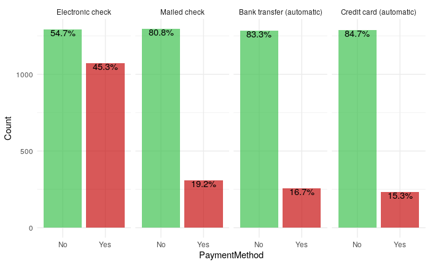

```r
Churn_vs_var_plot(churnDf, "PaymentMethod")
```

- **`PaymentMethod`** - Customers who have `ElectronicCheck` as their `PaymentMethod` tend to leave the platform more when compared to other options.

## Visualizing the three continuous variables with respect to `Churn`:

### Tenure

Show the distribution of tenure for each churn catergory with a boxplot, violinplot or both:

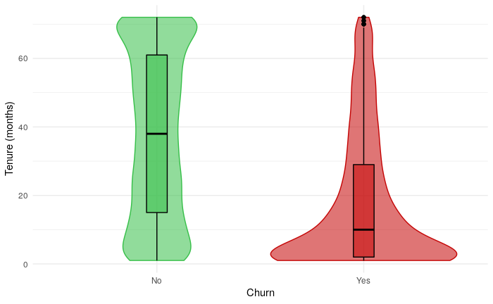

```r
ggplot(churnDf, aes(y = tenure, x = Churn, fill = Churn,
                    color = Churn, alpha = 1/2)) +
  geom_violin(trim = T, show.legend = F) +
  geom_boxplot(width = 0.1, show.legend = F, color = "black") +
  scale_fill_manual(values = c("#37bf49", "#c40505")) +
  scale_color_manual(values = c("#37bf49", "#c40505")) +
#  geom_jitter(size = 0.1, width = 0.05, alpha = 1/10, color = "black", show.legend = F) +
  labs(y = "Tenure (months)") +
  theme_minimal()
```

- **`tenure`** - Median tenure of customers who left is only 10 months, while the median for the group that hasn’t churned is about 38 months. We see many customers who use the service for just 1 month (perhaps tourists).

Let’s continue with exploring the `tenure` variable.

Adding a new variable called `tenureY` which will round months into integer years:

```r
churnDf <- churnDf %>%
  mutate(tenureY = ceiling(tenure/12))
```

Now we obtain a summary of the churnDf DF to calculate number of customers in each bin, avergae, number of churned customers in the bin, and churn rate:

```r
hist_summary <- churnDf %>%
  group_by(tenureY) %>%
  summarize(Freq = n(),
            n_churn = sum(Churn=='Yes')) %>%
  mutate(percentage = round(n_churn/Freq*100, 1))
hist_summary
```

| tenureY | Freq | n_churn | percentage |
| --- | --- | --- | --- |
| 1 | 2175 | 1037 | 47.7 |
| 2 | 1024 | 294 | 28.7 |
| 3 | 832 | 180 | 21.6 |
| 4 | 762 | 145 | 19.0 |
| 5 | 832 | 120 | 14.4 |
| 6 | 1407 | 93 | 6.6 |

Creating a histogram from the new tenure (year) variable and calculated values above. Also, adding a bar chart to shot the churn for each bucket:

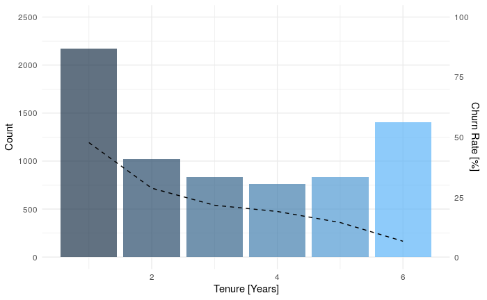

```r
hist_summary %>%
  ggplot() +
    geom_bar(aes(x = tenureY, y = Freq, fill = tenureY), width = 0.9,
             stat = "identity",
             show.legend = F, alpha = 2/3) +
    geom_line(aes(x = tenureY, y = percentage*25), linetype = "dashed") +
    labs(y = "Count", x = "Tenure [Years]") +
    scale_y_continuous(limits = c(0, 2500),
                       sec.axis = sec_axis(~./25, name = "Churn Rate [%]")) +
    theme_minimal()
```

### Monthly Charges

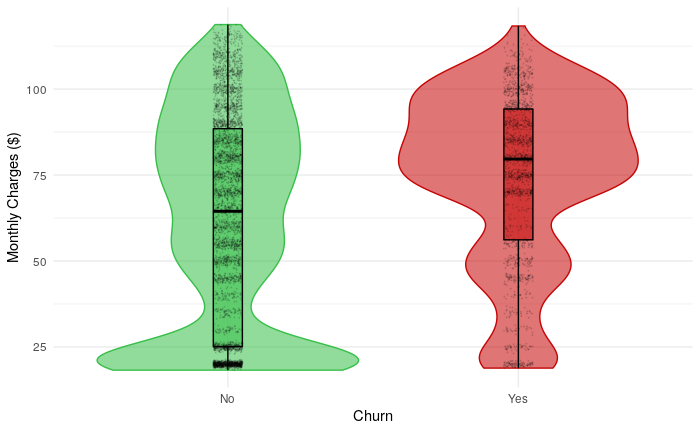

```r
ggplot(churnDf, aes(y = MonthlyCharges, x = Churn, fill = Churn, color = Churn, alpha = 1/2)) +
  geom_violin(trim = T, show.legend = F) +
  geom_boxplot(width = 0.1, show.legend = F, color = "black") +
  scale_fill_manual(values = c("#37bf49", "#c40505")) +
  scale_color_manual(values = c("#37bf49", "#c40505")) +
  geom_jitter(size = 0.1, width = 0.05, alpha = 1/10, color = "black", show.legend = F) +
  labs(y = "Monthly Charges ($)") +
  theme_minimal()
```

- **`MonthlyCharges`** - Customers who have churned have higher monthly charges on average

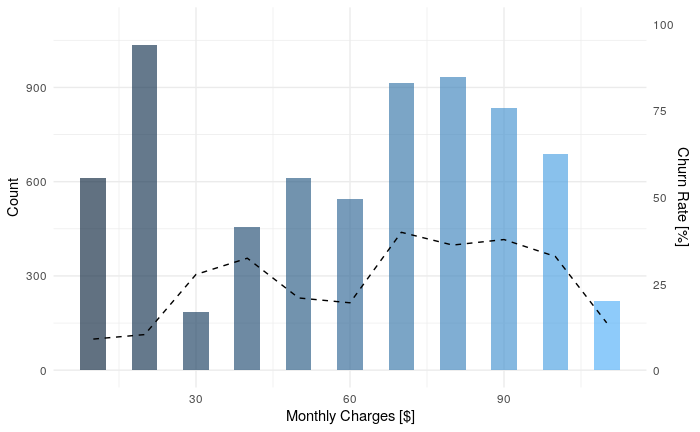

```r
# Monthly charge plot

# Creating bins for MonthlyCharges
churnDf <- churnDf %>%
  mutate(binCharges = (MonthlyCharges %/% 10) * 10)

# Now we obtain a summary of the churnDf DF to calculate number of customers in each bin, avergae, number of churned customers in the bin, and churn rate
hist_summary2 <- churnDf %>%
  group_by(binCharges) %>%
  summarize(Freq = n(),
            n_churn = sum(Churn=='Yes')) %>%
  mutate(percentage = round(n_churn/Freq*100, 1))

# Plot a bar chart based on the hist_summary. Dashed line shows the churn rate in each bucket
# Color of the bins correspond the average of MonthlyCharges in the bin
hist_summary2 %>%
  ggplot() +
    geom_bar(aes(x = binCharges, y = Freq, fill = binCharges), width = 5,
             stat = "identity",
             show.legend = F, alpha = 2/3) +
    geom_line(aes(x = binCharges, y = percentage*11), linetype = "dashed") +
    labs(y = "Count", x = "Monthly Charges [$]") +
    scale_y_continuous(limits = c(0, 1100),
                       sec.axis = sec_axis(~./11, name = "Churn Rate [%]")) +
    theme_minimal()
```

### Total Charges

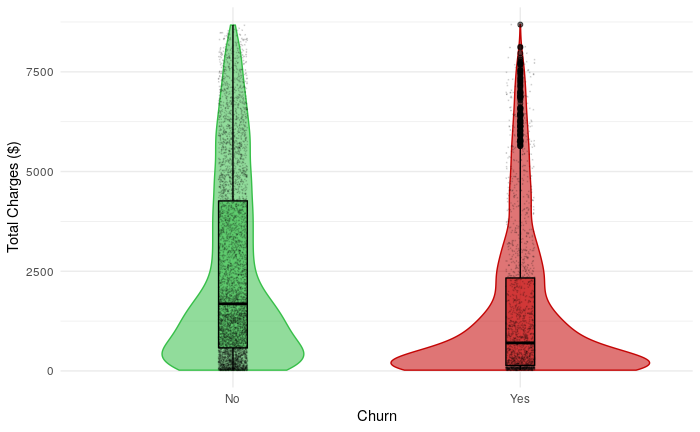

```r
ggplot(churnDf, aes(y = TotalCharges, x = Churn, fill = Churn, color = Churn, alpha = 1/2)) +
  geom_violin(trim = T, show.legend = F) +
  geom_boxplot(width = 0.1, show.legend = F, color = "black") +
  scale_fill_manual(values = c("#37bf49", "#c40505")) +
  scale_color_manual(values = c("#37bf49", "#c40505")) +
  geom_jitter(size = 0.1, width = 0.05, alpha = 1/10, color = "black", show.legend = F) +
  labs(y = "Total Charges ($)") +
  theme_minimal()
```

- **`TotalCharges`** - Customers who have churned have spent less money on average. This makes sense because their tenure is a lot shorter.

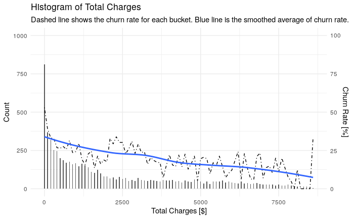

```r
# Total Charges

# Creating bins for MonthlyCharges
churnDf <- churnDf %>%
  mutate(binTotalCharges = (TotalCharges %/% 100) * 100)

# Now we obtain a summary of the churnDf DF to calculate number of customers in each bin, avergae, number of churned customers in the bin, and churn rate
hist_summary3 <- churnDf %>%
  group_by(binTotalCharges) %>%
  summarize(Freq = n(),
            n_churn = sum(Churn=='Yes')) %>%
  mutate(percentage = round(n_churn/Freq*100, 1))

# Plot a bar chart based on the hist_summary, adding a dashed line on top of it to show
#   the average of TotalCharges in each bin
hist_summary3 %>%
  ggplot() +
    scale_fill_gradient(low = "green", high = "red") +
    geom_bar(aes(x = binTotalCharges, y = Freq), width = 25, stat = "identity") +
    geom_line(aes(x = binTotalCharges, y = percentage*10), linetype="dotdash") +
    geom_smooth(aes(x = binTotalCharges, y = percentage*10), se = F) +
    labs(y = "Count", x = "Total Charges [$]",
         title = "Histogram of Total Charges",
         subtitle = "Dashed line shows the churn rate for each bucket. Blue line is the smoothed average of churn rate.") +
    scale_y_continuous(limits = c(0, 1000),
                       sec.axis = sec_axis(~./10, name = "Churn Rate [%]")) +
    theme_minimal()
```

### MonthlyCharges vs. TotalCharges

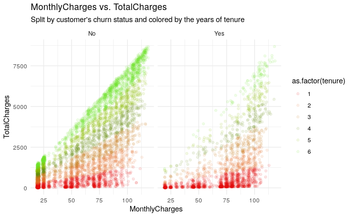

```r
churnDf %>%
  mutate(tenure = ceiling(tenure/12)) %>%
  ggplot(aes(MonthlyCharges, TotalCharges)) +
    geom_point(aes(color = as.factor(tenure)), alpha = 1/10) +
    facet_wrap(~Churn) +
    scale_color_manual(values = c("#e51010", "#e26d28", "#c67d1d", "#6a8e0e", "#8cbf09", "#6ee22f")) +
    labs(title = "MonthlyCharges vs. TotalCharges",
         subtitle = "Split by customer's churn status and colored by the years of tenure") +
    theme_minimal()
```

### Correlation matrix

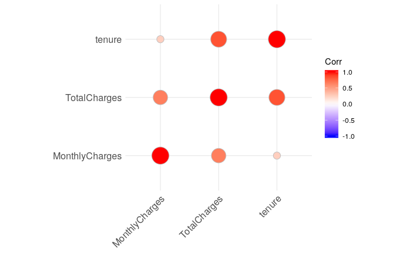

```r
cor_df <- round(cor(churnDf[c("MonthlyCharges", "TotalCharges", "tenure")]), 2)
ggcorrplot(cor_df, method = "circle")
```

As expected `tenure` and `TotalCharges` as well as `MonthlyCharges` and `TotalCharges` are highly correlated.

### Average Monthly Charges by Tenure Groups

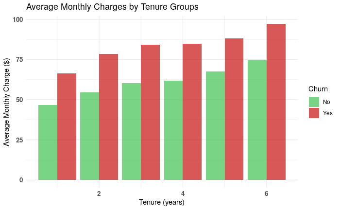

```r
churnDf %>%
  group_by(tenureY, Churn) %>%
  summarize(avg_monthly_charges = mean(MonthlyCharges, na.rm = T)) %>%
  ggplot(aes(x = tenureY, y = avg_monthly_charges, fill = Churn)) +
    geom_bar(stat = "identity", position = "dodge", alpha = 2/3) +
    scale_fill_manual( values = c("#37bf49", "#c40505")) +
    labs(x = "Tenure (years)", y = "Average Monthly Charge ($)",
         title = "Average Monthly Charges by Tenure Groups") +
    theme_minimal() +
    theme(axis.text.x = element_text(face="bold", size=10),
          axis.text.y = element_text(face="bold", size=10))
```

### Average Total Charges by Tenure Groups

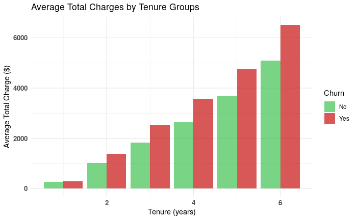

```r
churnDf %>%
  mutate(tenureY = ceiling(tenure/12)) %>%
  group_by(tenureY, Churn) %>%
  summarize(avg_monthly_charges = mean(TotalCharges, na.rm = T)) %>%
  ggplot(aes(x = tenureY, y = avg_monthly_charges, fill = Churn)) +
    geom_bar(stat = "identity", position = "dodge", alpha = 2/3) +
    scale_fill_manual( values = c("#37bf49", "#c40505")) +
    labs(x = "Tenure (years)", y = "Average Total Charge ($)",
         title = "Average Total Charges by Tenure Groups") +
    theme_minimal() +
    theme(axis.text.x = element_text(face="bold", size=10),
          axis.text.y = element_text(face="bold", size=10))
```

# Modeling

Note: modeling is not generally considered a part of the EDA process. This is just a brief extra session to showcase a simple predictive analysis workflow in R.

## Split test/training sets

Before training the model we should set aside a “test” set for model evaluation. We will take 25% of the records at random for testing.

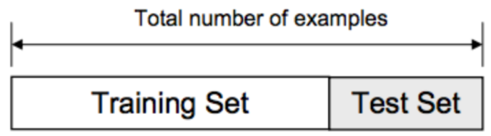

```r
set.seed(1)
churnDfML <- select(churnDf, -c(tenureY, binCharges, binTotalCharges))
train_test_split <- rsample::initial_split(churnDfML, prop = 0.75)

# Retrieve train and test sets
train_df <- rsample::training(train_test_split)
test_df  <- rsample::testing(train_test_split)
print(paste0("records in train dataset: ", nrow(train_df)))
```

```
[1] "records in train dataset: 5274"
```

```r
print(paste0("records in test dataset: ", nrow(test_df)))
```

```
[1] "records in test dataset: 1758"
```

**One-hot encoding**: transforming categorical variables into separate features. All non-numeric variables will need to be converted to categorical (dummy) variables. This is known as one-hot encoding.

## Preprocessing with Recipes package

Before feeding the training data into the model we need to perform some preprocessing steps on the data. These steps can include one-hot encoding, transformation (e.g., log transformation), scaling, centering, etc.

With **recipes** we can create a “recipe” for how these steps should be applied to the data. We then use this recipe on both train and test datasets to apply the necessary changes to them.

```r
data.frame(churnDf, stringsAsFactors = T)
```

| Churn | gender | SeniorCitizen | Partner | Dependents | tenure | PhoneService | MultipleLines | InternetService | OnlineSecurity | OnlineBackup | DeviceProtection | TechSupport | StreamingTV | StreamingMovies | Contract | PaperlessBilling | PaymentMethod | MonthlyCharges | TotalCharges | tenureY | binCharges | binTotalCharges |
| --- | --- | --- | --- | --- | --- | --- | --- | --- | --- | --- | --- | --- | --- | --- | --- | --- | --- | --- | --- | --- | --- | --- |
| No | Female | No | Yes | No | 1 | No | No phone service | DSL | No | Yes | No | No | No | No | Month-to-month | Yes | Electronic check | 29.85 | 29.85 | 1 | 20 | 0 |
| No | Male | No | No | No | 34 | Yes | No | DSL | Yes | No | Yes | No | No | No | One year | No | Mailed check | 56.95 | 1889.50 | 3 | 50 | 1800 |
| Yes | Male | No | No | No | 2 | Yes | No | DSL | Yes | Yes | No | No | No | No | Month-to-month | Yes | Mailed check | 53.85 | 108.15 | 1 | 50 | 100 |
| No | Male | No | No | No | 45 | No | No phone service | DSL | Yes | No | Yes | Yes | No | No | One year | No | Bank transfer (automatic) | 42.30 | 1840.75 | 4 | 40 | 1800 |
| Yes | Female | No | No | No | 2 | Yes | No | Fiber optic | No | No | No | No | No | No | Month-to-month | Yes | Electronic check | 70.70 | 151.65 | 1 | 70 | 100 |
| Yes | Female | No | No | No | 8 | Yes | Yes | Fiber optic | No | No | Yes | No | Yes | Yes | Month-to-month | Yes | Electronic check | 99.65 | 820.50 | 1 | 90 | 800 |
| No | Male | No | No | Yes | 22 | Yes | Yes | Fiber optic | No | Yes | No | No | Yes | No | Month-to-month | Yes | Credit card (automatic) | 89.10 | 1949.40 | 2 | 80 | 1900 |
| No | Female | No | No | No | 10 | No | No phone service | DSL | Yes | No | No | No | No | No | Month-to-month | No | Mailed check | 29.75 | 301.90 | 1 | 20 | 300 |
| Yes | Female | No | Yes | No | 28 | Yes | Yes | Fiber optic | No | No | Yes | Yes | Yes | Yes | Month-to-month | Yes | Electronic check | 104.80 | 3046.05 | 3 | 100 | 3000 |
| No | Male | No | No | Yes | 62 | Yes | No | DSL | Yes | Yes | No | No | No | No | One year | No | Bank transfer (automatic) | 56.15 | 3487.95 | 6 | 50 | 3400 |

[output cut: 990 more lines]

```r
# A recipe is a description of what steps should be applied to a data set in order to get it ready for data analysis.
recipe_obj <- recipes::recipe(Churn ~ ., data = train_df) %>%  # object = Churn ~ . meaning “Churn” is the outcome and all other features are predictors
  recipes::step_discretize(tenure, options = list(cuts = 6)) %>%  #  convert numeric data into a factor with bins having approximately the same number of data points (based on the training set)
  recipes::step_log(TotalCharges) %>%  # creates a specification of a recipe step that will log transform the variable
  recipes::step_dummy(all_nominal(), -all_outcomes()) %>%  # creates a a specification of a recipe step that will convert nominal data into one or more numeric binary
  recipes::prep(data = train_df)  # estimates the required parameters from a training set that can be later applied to other data sets

# Print the recipe object
recipe_obj
```

```
Data Recipe

Inputs:

      role #variables
   outcome          1
 predictor         19

Training data contained 5274 data points and no missing data.

Operations:

Dummy variables from tenure [trained]
Log transformation on TotalCharges [trained]
Dummy variables from gender, SeniorCitizen, Partner, Dependents, tenure, ... [trained]
```

```r
all_outcomes()
```

```
[1] 20
```

### Applying the recipe

We can apply our “recipe” to any data set with `bake()` function. It processes the data following the steps specified in the recipe.

```r
# Baking of train and test datasets (predictors only)
train <- recipes::bake(recipe_obj, new_data = train_df)
test  <- recipes::bake(recipe_obj, new_data = test_df)
glimpse(train)
```

```
Observations: 5,274
Variables: 36
$ Churn                                   <fct> No, No, Yes, No, Yes, Yes, No, No, No, N…
$ MonthlyCharges                          <dbl> 29.85, 56.95, 53.85, 42.30, 70.70, 99.65…
$ TotalCharges                            <dbl> 3.396185, 7.544068, 4.683519, 7.517928, …
$ gender_Male                             <dbl> 0, 1, 1, 1, 0, 0, 1, 0, 1, 1, 1, 1, 0, 0…
$ SeniorCitizen_Yes                       <dbl> 0, 0, 0, 0, 0, 0, 0, 0, 0, 0, 0, 0, 0, 0…
$ Partner_No                              <dbl> 0, 1, 1, 1, 1, 1, 1, 1, 0, 1, 1, 1, 0, 1…
$ Dependents_Yes                          <dbl> 0, 0, 0, 0, 0, 0, 1, 0, 1, 0, 0, 0, 1, 0…
$ tenure_bin1                             <dbl> 1, 0, 1, 0, 1, 0, 0, 0, 0, 0, 0, 0, 0, 0…
$ tenure_bin2                             <dbl> 0, 0, 0, 0, 0, 1, 0, 1, 1, 0, 0, 0, 0, 0…
$ tenure_bin3                             <dbl> 0, 0, 0, 0, 0, 0, 1, 0, 0, 1, 0, 1, 0, 0…
$ tenure_bin4                             <dbl> 0, 1, 0, 1, 0, 0, 0, 0, 0, 0, 0, 0, 0, 0…
$ tenure_bin5                             <dbl> 0, 0, 0, 0, 0, 0, 0, 0, 0, 0, 1, 0, 0, 1…
$ tenure_bin6                             <dbl> 0, 0, 0, 0, 0, 0, 0, 0, 0, 0, 0, 0, 1, 0…
```

[output cut: 23 more lines]

## Train a logistic regression model

```r
model <- glm(Churn ~., family = "binomial", data = train)
summary(model)
```

```
Call:
glm(formula = Churn ~ ., family = "binomial", data = train)

Deviance Residuals:
    Min       1Q   Median       3Q      Max
-2.1468  -0.6705  -0.2907   0.5735   3.1523

Coefficients: (8 not defined because of singularities)
                                         Estimate Std. Error z value Pr(>|z|)
(Intercept)                              4.001831   1.370622   2.920 0.003503 **
MonthlyCharges                          -0.027034   0.036557  -0.740 0.459601
TotalCharges                            -0.621278   0.112973  -5.499 3.81e-08 ***
gender_Male                             -0.082835   0.075893  -1.091 0.275067
SeniorCitizen_Yes                        0.253203   0.098497   2.571 0.010150 *
Partner_No                              -0.029765   0.091440  -0.326 0.744796
Dependents_Yes                          -0.048985   0.104033  -0.471 0.637738
tenure_bin1                              0.055986   0.452921   0.124 0.901624
tenure_bin2                              0.041764   0.296330   0.141 0.887919
tenure_bin3                             -0.016271   0.236176  -0.069 0.945074
tenure_bin4                              0.153490   0.205692   0.746 0.455538
tenure_bin5                             -0.006856   0.195173  -0.035 0.971977
tenure_bin6                                    NA         NA      NA       NA
PhoneService_Yes                         0.772952   0.928680   0.832 0.405233
MultipleLines_No                        -0.479803   0.205701  -2.333 0.019673 *
MultipleLines_Yes                              NA         NA      NA       NA
InternetService_Fiber.optic              1.817149   0.917163   1.981 0.047561 *
InternetService_No                      -2.190870   1.110702  -1.973 0.048552 *
OnlineSecurity_Yes                      -0.162421   0.206167  -0.788 0.430805
OnlineSecurity_No.internet.service             NA         NA      NA       NA
OnlineBackup_No                         -0.065043   0.201586  -0.323 0.746957
OnlineBackup_No.internet.service               NA         NA      NA       NA
DeviceProtection_Yes                     0.159143   0.202206   0.787 0.431261
DeviceProtection_No.internet.service           NA         NA      NA       NA
TechSupport_Yes                         -0.128295   0.208392  -0.616 0.538129
TechSupport_No.internet.service                NA         NA      NA       NA
StreamingTV_Yes                          0.636506   0.376285   1.692 0.090731 .
StreamingTV_No.internet.service                NA         NA      NA       NA
StreamingMovies_Yes                      0.668050   0.375806   1.778 0.075462 .
StreamingMovies_No.internet.service            NA         NA      NA       NA
Contract_One.year                       -0.692123   0.124975  -5.538 3.06e-08 ***
Contract_Two.year                       -1.645478   0.211621  -7.776 7.51e-15 ***
PaperlessBilling_No                     -0.239858   0.088586  -2.708 0.006776 **
PaymentMethod_Mailed.check              -0.398016   0.114800  -3.467 0.000526 ***
PaymentMethod_Bank.transfer..automatic. -0.154703   0.110566  -1.399 0.161756
PaymentMethod_Credit.card..automatic.   -0.266395   0.111801  -2.383 0.017184 *
---
Signif. codes:  0 ‘***’ 0.001 ‘**’ 0.01 ‘*’ 0.05 ‘.’ 0.1 ‘ ’ 1

(Dispersion parameter for binomial family taken to be 1)

    Null deviance: 6087.6  on 5273  degrees of freedom
Residual deviance: 4302.0  on 5246  degrees of freedom
AIC: 4358

Number of Fisher Scoring iterations: 6
```

```r
# Model Evaluation using the test data:
prob <- predict(model, type = "response", newdata = test[,-1])
```

```
prediction from a rank-deficient fit may be misleading
```

```r
test$prob <- prob

# Using probability cutoff of 50%.
pred <- factor(ifelse(prob >= 0.50, "Yes", "No"))
actual_churn <- test$Churn
table(actual_churn, pred)
```

```
            pred
actual_churn   No  Yes
         No  1168  113
         Yes  223  254
```

```r
conf_final <- confusionMatrix(pred, actual_churn, positive = "Yes")
conf_final
```

```
Confusion Matrix and Statistics

          Reference
Prediction   No  Yes
       No  1168  223
       Yes  113  254

               Accuracy : 0.8089
                 95% CI : (0.7897, 0.827)
    No Information Rate : 0.7287
    P-Value [Acc > NIR] : 2.881e-15

                  Kappa : 0.4789

 Mcnemar's Test P-Value : 2.740e-09

            Sensitivity : 0.5325
            Specificity : 0.9118
         Pos Pred Value : 0.6921
         Neg Pred Value : 0.8397
             Prevalence : 0.2713
         Detection Rate : 0.1445
   Detection Prevalence : 0.2088
      Balanced Accuracy : 0.7221

       'Positive' Class : Yes
```

```r
accuracy <- conf_final$overall[1]
sensitivity <- conf_final$byClass[1]
specificity <- conf_final$byClass[2]
auc <- c(AUC = pROC::roc(response = test$Churn, predictor = as.numeric(pred)) %>% auc)
accuracy
```

```
 Accuracy
0.8088737
```

```r
sensitivity
```

```
Sensitivity
  0.5324948
```

```r
specificity
```

```
Specificity
  0.9117877
```

```r
auc
```

```
      AUC
0.7221412
```

- **Accuracy**: percentage of correct guesses
- **Sensitivity** (also called the true positive rate, the recall, or probability of detection): measures the proportion of actual positives that are correctly identified as such (e.g., the percentage of sick people who are correctly identified as having the condition).
- **Specificity** (also called the true negative rate): measures the proportion of actual negatives that are correctly identified as such (e.g., the percentage of healthy people who are correctly identified as not having the condition).
- **AUC**: the area under the ROC curve. This means our model has a 72% chance to assign a probability to a randomly chosen churning customer which is higher than a randomly chosen non-churning customer.

```r
perform_fn <- function(prob, cutoff)
{
  predicted_churn <- factor(ifelse(prob >= cutoff, "Yes", "No"))
  conf <- confusionMatrix(predicted_churn, actual_churn, positive = "Yes")
  sensitivity <- conf$byClass[1]
  specificity <- conf$byClass[2]
  out <- t(as.matrix(c(sensitivity, specificity)))
  colnames(out) <- c("sensitivity", "specificity")
  return(out)
}

s = seq(0.01,0.80,length=100)
OUT = matrix(0,100,2)

for(i in 1:100)
{
  OUT[i,] = perform_fn(prob, s[i])
}

plot(s, OUT[,1], xlab = "Cutoff", ylab = "Value", cex.lab = 1.5, cex.axis = 1.5, ylim = c(0,1),
     type = "l", lwd = 2, axes = FALSE, col = 2)
axis(1, seq(0, 1, length = 5), seq(0, 1, length = 5), cex.lab = 1.5)
```

```r
axis(2, seq(0, 1, length = 5), seq(0, 1, length = 5), cex.lab = 1.5)
lines(s, OUT[,2], col = "darkgreen", lwd = 2)
```

```r
box()
legend("bottom", col = c(2, "darkgreen", 4, "darkred"), text.font = 3, inset = 0.02,
       box.lty = 0, cex = 0.8,
       lwd = c(2,2,2,2), c("Sensitivity", "Specificity"))
```

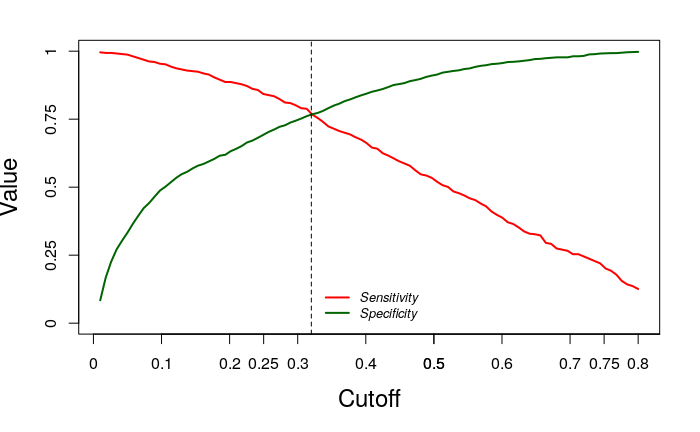

```r
abline(v = 0.32, col = "black", lwd = 1, lty = 2)
axis(1, at = seq(0.1, 1, by = 0.1))
```

```r
prediced_churn <- factor(ifelse(prob >=0.32, "Yes", "No"))
conf_final <- confusionMatrix(prediced_churn, actual_churn, positive = "Yes")
accuracy <- conf_final$overall[1]
sensitivity <- conf_final$byClass[1]
specificity <- conf_final$byClass[2]
auc <- c(AUC = pROC::roc(response = test$Churn, predictor = as.numeric(prediced_churn)) %>% auc)
table(actual_churn, prediced_churn)
```

```
            prediced_churn
actual_churn  No Yes
         No  982 299
         Yes 109 368
```

```r
accuracy
```

```
 Accuracy
0.7679181
```

```r
sensitivity
```

```
Sensitivity
  0.7714885
```

```r
specificity
```

```
Specificity
  0.7665886
```

```r
auc
```

```
      AUC
0.7690385
```

```r
predicted_test <- as.tibble(cbind(prediced_churn, test))
```

```
`as.tibble()` is deprecated, use `as_tibble()` (but mind the new semantics).
```

```r
predicted_test
```

| prediced_churn | Churn | MonthlyCharges | TotalCharges | gender_Male | SeniorCitizen_Yes | Partner_No | Dependents_Yes | tenure_bin1 | tenure_bin2 | tenure_bin3 | tenure_bin4 | tenure_bin5 | tenure_bin6 | PhoneService_Yes | MultipleLines_No | MultipleLines_Yes | InternetService_Fiber.optic | InternetService_No | OnlineSecurity_Yes | OnlineSecurity_No.internet.service | OnlineBackup_No | OnlineBackup_No.internet.service | DeviceProtection_Yes | DeviceProtection_No.internet.service | TechSupport_Yes | TechSupport_No.internet.service | StreamingTV_Yes | StreamingTV_No.internet.service | StreamingMovies_Yes | … |
| --- | --- | --- | --- | --- | --- | --- | --- | --- | --- | --- | --- | --- | --- | --- | --- | --- | --- | --- | --- | --- | --- | --- | --- | --- | --- | --- | --- | --- | --- | --- |
| Yes | Yes | 104.80 | 8.021601 | 0 | 0 | 0 | 0 | 0 | 0 | 1 | 0 | 0 | 0 | 1 | 0 | 1 | 1 | 0 | 0 | 0 | 1 | 0 | 1 | 0 | 1 | 0 | 1 | 0 | 1 | … |
| No | No | 56.15 | 8.157069 | 1 | 0 | 1 | 1 | 0 | 0 | 0 | 0 | 1 | 0 | 1 | 1 | 0 | 0 | 0 | 1 | 0 | 0 | 0 | 0 | 0 | 0 | 0 | 0 | 0 | 0 | … |
| No | No | 100.35 | 8.644900 | 1 | 0 | 0 | 0 | 0 | 0 | 0 | 0 | 1 | 0 | 1 | 0 | 1 | 1 | 0 | 0 | 0 | 1 | 0 | 1 | 0 | 0 | 0 | 1 | 0 | 1 | … |
| No | Yes | 55.20 | 6.269759 | 0 | 0 | 0 | 1 | 0 | 1 | 0 | 0 | 0 | 0 | 1 | 1 | 0 | 0 | 0 | 0 | 0 | 1 | 0 | 1 | 0 | 1 | 0 | 0 | 0 | 0 | … |
| No | No | 55.30 | 7.333415 | 0 | 0 | 1 | 0 | 0 | 0 | 0 | 1 | 0 | 0 | 1 | 1 | 0 | 0 | 0 | 1 | 0 | 0 | 0 | 0 | 0 | 0 | 0 | 0 | 0 | 0 | … |
| No | No | 96.35 | 8.819806 | 0 | 1 | 0 | 0 | 0 | 0 | 0 | 0 | 0 | 1 | 1 | 0 | 1 | 1 | 0 | 1 | 0 | 0 | 0 | 1 | 0 | 1 | 0 | 0 | 0 | 0 | … |
| Yes | No | 45.25 | 3.812203 | 1 | 1 | 1 | 0 | 1 | 0 | 0 | 0 | 0 | 0 | 1 | 1 | 0 | 0 | 0 | 0 | 0 | 1 | 0 | 0 | 0 | 0 | 0 | 0 | 0 | 0 | … |
| No | No | 69.20 | 8.491332 | 0 | 0 | 0 | 1 | 0 | 0 | 0 | 0 | 0 | 1 | 1 | 0 | 1 | 0 | 0 | 1 | 0 | 0 | 0 | 0 | 0 | 0 | 0 | 1 | 0 | 0 | … |
| No | No | 79.85 | 8.489092 | 0 | 0 | 1 | 0 | 0 | 0 | 0 | 0 | 1 | 0 | 1 | 0 | 1 | 0 | 0 | 1 | 0 | 0 | 0 | 1 | 0 | 1 | 0 | 1 | 0 | 0 | … |
| No | No | 76.20 | 6.889031 | 0 | 0 | 0 | 0 | 0 | 1 | 0 | 0 | 0 | 0 | 1 | 0 | 1 | 0 | 0 | 1 | 0 | 0 | 0 | 0 | 0 | 1 | 0 | 1 | 0 | 0 | … |

[output cut: 990 more lines]

```r
table(actual_churn, prediced_churn)
```

```
            prediced_churn
actual_churn  No Yes
         No  982 299
         Yes 109 368
```

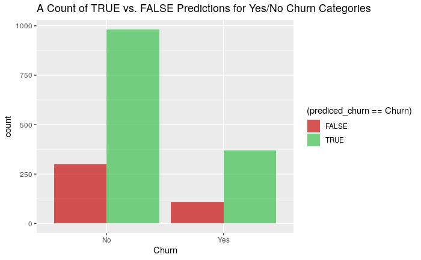

```r
predicted_test %>%
  ggplot() +
    geom_bar(aes(x = Churn, fill = (prediced_churn == Churn)), position = "dodge", alpha = 2/3) +
    scale_fill_manual( values = c("#c40505", "#37bf49")) +
    labs(title = "A Count of TRUE vs. FALSE Predictions for Yes/No Churn Categories")
```

Actual/Prediction

- No/No (green in the No bucket): True Negative - We accurately labeled these customers at no risk! **:-)**
- Yes/Yes (green in the Yes bucket): True Positive - We accurately predicted these churning customers! **:-)**
- No/Yes (red in the No bucket): False Positive - We thought they were leaving but they didn’t! **:-|**
- Yes/No (red in the Yes bucket): False Negative - We failed to predict these churning customers! **:-(**